# Chapter5 Statistics-Hypothesis Testing : Ravi Mummigatti : 26-12-20

# Descriptive v/s Inferential Statistics

**Descriptive statistics is all about summarizing data**. It is useful for making large amounts of information into an interpretable subset of numbers and/or visualizations.  
Commonly used descriptive statistics include the average, median, frequency, standard deviation, and range of a set of values. These numeric descriptive statistics can also be displayed as visual representations, such as tables and graphs.  
**Inferential statistics is all about using a sample (a subset of a population) to make inferences about a larger population of interest**. This is useful when we want to know something about a population but cannot observe every member — often due to time, feasibility, or monetary constraints. Some methods that are used in inferential statistics include hypothesis testing and regression.  
The key to inferential statistics is understanding that samples do not always accurately reflect the population they came from. A large part of inferential statistics is quantifying our uncertainty about a population by looking at a smaller sample.

# The Central Limit Theorem

The Central Limit Theorem (CLT) is a powerful statistical tool that is useful in quantifying uncertainty around sample mean estimates. It is also the basis for common hypothesis tests, such as Z- and t-tests.

## Building intuition for the CLT

Imagine that a data scientist wants to know the average hourly wage for all working U.S. adults who make under 150 dollars per hour. This is a very large population — it would be unrealistic to collect wage data for every person meeting these criteria. Instead, suppose that the data scientist surveys a random sample of 150 people, records each person’s hourly wage, and calculates a sample mean of 17.74 dollars per hour.  
Here’s a histogram of this sample, with a black dotted line at 17.74:

[figure not shown]

A good data scientist knows that this sample mean is not EXACTLY the same as the population mean, but hopes that it is close ENOUGH. The next question is:

How far from the population mean could this sample mean realistically be?

To answer this, let’s temporarily pretend that we are all-knowing and can actually inspect the hourly wages of all people in the population of interest.  
Suppose that the true average wage is 18.84 dollars per hour and a histogram of the full population looks like this

[figure not shown]

In real life, we usually only observe a single sample — but in order to quantify our uncertainty about that sample, it is useful to think about what WOULD happen if we could observe more

Consider the following thought experiment:  
Umagine that we could take some large number (say, 10,000) random samples of 150 people from the population and calculate the mean hourly wage for each of those samples.  
We could then inspect the 10,000 sample means to see how much they vary.  
A large amount of variation would make us less confident that any individual sample mean is representative of the population; less variation would make us more confident.  
After collecting 10,000 sample means, we can inspect them using a histogram.

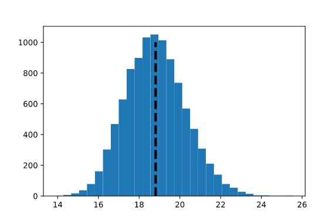

There are a few interesting things to notice about this distribution, which is called the sampling distribution of the mean:

1. Unlike the population distribution, which is very right-skewed, this distribution is (almost) normally distributed: symmetric with a single mode.
2. The average of the sample means (black dotted line) is approximately equal to the population mean (18.84).
3. The 10,000 sample means range approximately between 14 and 24 (plus or minus 5 dollars from the true mean).

## Formally defining the CLT

It’s now time to formally define the CLT, which tells us that the sampling distribution of the mean:

1. is normally distributed (for large enough sample size)
2. is centered at the population mean
3. has standard deviation equal to the population standard deviation divided by the square root of the sample size. This is called Standard Error.

With respect to the standard error formula described above, note that there are two levers on the width of the sampling distribution:

1. The population standard deviation. Populations with more variation will yield sample means with more variation. For example, imagine sampling the heights of 5 year olds compared to sampling heights of 5-18 year olds. There is more variation in the heights of 5-18 year olds, so there will be more variation in individual samples.
2. The sample size. The larger the sample size, the smaller the variation in repeated sample means. In the wage example above, imagine sampling only five people instead of 150. Those five sampled people could include one outlier that throws the whole sample mean off. If we sample 150 (or even more) people, we’re more likely to have high and low outliers that cancel each other out.

# Introduction to Hypothesis Testing

## What is hypothesis testing?

Hypothesis Testing is a framework for asking questions about a dataset and answering them with probabilistic statements.  
There are many different kinds of hypothesis tests that can be used to address different kinds of questions and data.  
We will walk through a simulation of a one sample t- test in order to build intuition about how many different kinds of hypothesis tests work!

### Step 1: Ask a Question

The International Baccalaureate Degree Programme (IBDP) is a world-wide educational program. Each year, students in participating schools can take a standardized assessment to earn their degree. Total scores on this assessment range from 1-45. Based on data provided here, the average total score for all students who took this exam in May 2020 was around 29.92. The distribution of scores looks something like this:

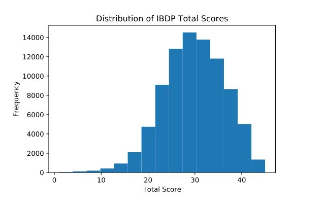

Imagine a hypothetical online school, Statistics Academy, that offers a 5-week test-preparation program.  
Suppose that 100 students who took the IBDP assessment in May 2020 were randomly chosen to participate in the first cohort of this program and that these 100 students earned an average score of 31.16 points on the exam — about 1.24 points higher than the international average! Are these students really outperforming their peers? Or could this difference be attributed to random chance?

### Step 2: Define the Null and Alternative Hypotheses

A hypothesis test begins with two competing hypotheses about the population that a particular sample comes from — in this case, the 100 Statistics Academy students:

**Hypothesis 0 (technically called the Null Hypothesis): This is the Hypothesis of "No Change"**  
The 100 Statistics Academy students are a random sample from the general population of test takers, who had an average score of **29.92**.

If this hypothesis is true, the Statistics Academy students earned a slightly higher average score by random chance.

Visually, this set-up looks something like this:

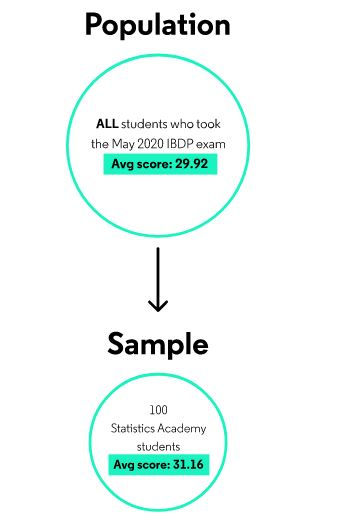

**Hypothesis A (technically called the Alternative Hypothesis): This is the Hypothesis of Change / Difference**  
The 100 Statistics Academy students came from a population with an average score that is different from 29.92.  
In this hypothesis, we need to imagine two different populations that don’t actually exist:

- one where all students took the Statistics Academy test-prep program and
- one where none of the students took the program. If the alternative hypothesis is true, our sample of 100

Statistics Academy students came from a different population than the other test-takers. This can be visualized as follows:

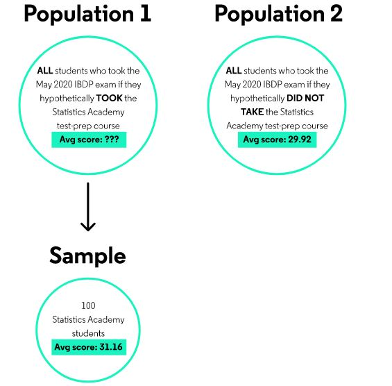

There’s one more clarification we need to make in order to fully specify the alternative hypothesis.

Notice that, so far, we have not said anything about the average score for “population 1” in the diagram above, other than that it is NOT 29.92.  
We actually have three choices for what the alternative hypothesis says about this population average:  
(1) it is GREATER THAN 29.92  
(2) it is NOT EQUAL TO (i.e., GREATER THAN OR LESS THAN) 29.92  
(3) it is LESS THAN 29.92

#### Practice Formulating a Hypothesis

Suppose that a random sample of 300 runners in the Boston Marathon were chosen to run in a new model of shoes: the Flying Flier. The average finishing time for these 300 runners was 230 minutes, while the average finishing time for all runners was 233 minutes. Was the average finishing time for this sample significantly different from the average finishing time for all runners?

*Null Hypothesis : The average finishing time for Boston Marathon runners wearing the Flying Flyer is equql to 233*  
*Alternate Hypothesis : The average finishing time for Boston Marathon runners wearing the Flying Flyer not equal to 233*

### Step 3: Determine the Null Distribution

Now that we have our *null hypothesis*, we can generate a *null distribution*: the distribution of the sample statistic we are interested in if the null hypothesis is true

In the IBDP example described above, this is the distribution of average scores for repeated samples of size 100 drawn from a population with an average score of 29.92  
We can do this by:

- Taking many random samples of 100 scores, each, from the population
- Calculating and storing the average score for each of those samples
- Plotting a histogram of the average scores

This yields the following distribution, which is approximately normal and centered at the population average:

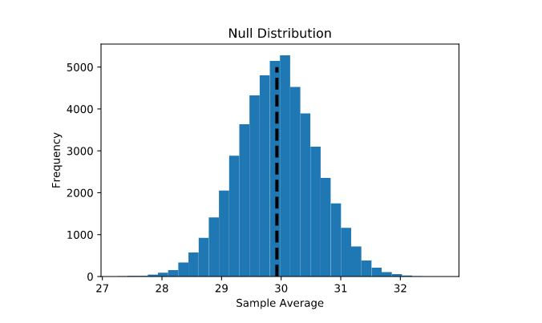

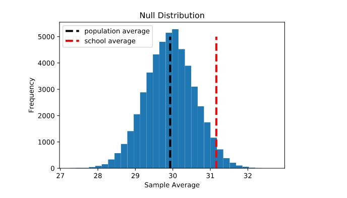

### Step 4: Calculate a P-Value (or Confidence Interval)

Given that the null hypothesis is true (that the 100 students from Statistics Academy were sampled from a population with an average IBDP score of 29.92), how likely is it that their average score is 31.16?

The minor problem with this question is that the probability of any exact average score is very small, so we really want to estimate the probability of a range of scores. Let’s now return to our three possible alternative hypotheses and see how the question and calculation each change slightly, depending on which one we choose:

#### Option 1 : One Sided / One Tailed / Right Side / Greater Than

**Alternative Hypothesis: The sample of 100 scores earned by Statistics Academy students came from a population with an average score that is greater than 29.92.**

In this case, we want to know the **probability** of observing a sample average greater than or equal to 31.16 given that the null hypothesis is true.  
Visually, this is the proportion of the null distribution that is greater than or equal to 31.16 (shaded in red below).  
Here, the red region makes up about 3.1% of the total distribution.  
This proportion, which is usually written in decimal form (i.e., 0.031), is called a **p-value.**

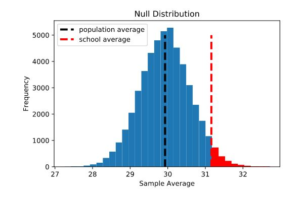

#### Option 2 : Two Sided / Two Tailed

**Alternative Hypothesis: The sample of 100 scores earned by Statistics Academy students came from a population with an average score that is not equal to (i.e.> OR <) 29.92.**

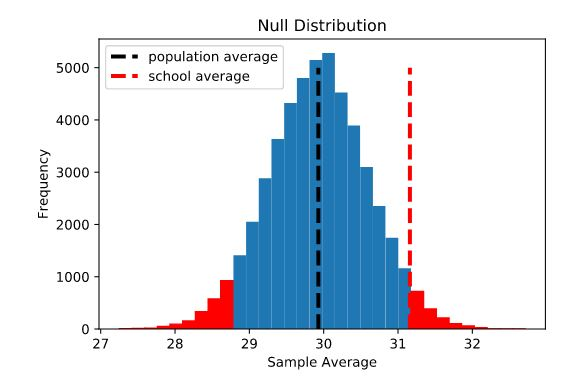

While option 1 is often referred to as a One Sided or One-Tailed test, this version is referred to as a Two Sided or Two-Tailed test, referencing the two tails of the null distribution that are counted in the p-value.  
**It is important to note that most hypothesis testing functions in Python and R implement a two-tailed test by default**

#### Option 3 : One Sided / One Tailed / Left SIde / Less Than

**Alternative Hypothesis: The sample of 100 scores earned by Statistics Academy students came from a population with an average score that is less than 29.92**.

Here, we want to know the probability of observing a sample average less than or equal to 31.16, given that the null hypothesis is true. This is also a one-sided test, just the opposite side from option 1.  
Visually, this is the proportion of the null distribution that is less than or equal to 31.16.  
This is a very large area (almost 97% of the distribution!), leading to a p-value of 0.969.

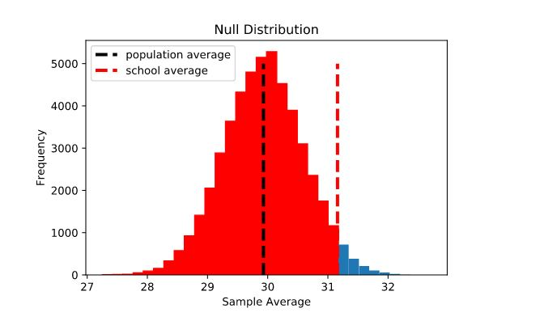

### Step 5: Interpret the Results

In the three examples above, we calculated three different p-values (0.031, 0.062, and 0.969, respectively).

Consider the first p-value of 0.031. The interpretation of this number is as follows:

*If the 100 students at Statistics Academy were randomly selected from the full population (which had an average score of 29.92), there is a 3.1% chance of their average score being 31.16 points or higher.*

This means that it is relatively unlikely, but not impossible, that the Statistics Academy students scored higher (on average) than their peers by random chance, despite no real difference at the population level. In other words, the observed data is unlikely if the null hypothesis is true.  
**Note that we have directly tested the null hypothesis, but not the alternative hypothesis!**

We need to be careful about how we interpret this test: we cannot say that we’ve proved that the alternative hypothesis is the truth — only that the data we collected would be unlikely under null hypothesis, and therefore we believe that the alternative hypothesis is more consistent with our observations.

#### Practice Interpretation

Suppose that a random sample of 300 runners in the Boston Marathon were chosen to run in a new model of shoes: the Flying Flier. The average finishing time for these 300 runners was 230 minutes, while the average finishing time for all runners was 233 minutes.  
We ran a **2-sided one-sample t-test** with the following null and alternative hypotheses:  
**Null Hypothesis: The average finishing time for Boston Marathon runners wearing the Flying Flyer is equal to 233 minutes.**  
**Alternative Hypothesis: The average finishing time for Boston Marathon runners wearing the Flying Flyer is not equal to 233 minutes**  
**We get a p-value of 0.10 for this test**

**Interpretation : If the 300 runners were randomly selected from the full population of runners (who had an average finishing time of 233 minutes), there is a 10% chance of their average finishing time being at least 3 minutes different from the average finishing time of all runners.**

# Significance thresholds

If the p-value is less than or equal to the significance level, then the null hypothesis is rejected in favor of the alternative hypothesis. And, if the p-value is greater than the significance level, then the null hypothesis is not rejected.

While it is reasonable to report a p-value, many data scientists use a **predetermined threshold** to decide whether a particular p-value is significant or not.

P-values below the chosen threshold are declared significant and lead the data scientist to “reject the null hypothesis in favor of the alternative”.  
A common choice for this threshold, which is also sometimes referred to as **Alpha, is 0.05** — but this is an arbitrary choice! Using a lower threshold means you are less likely to find significant results, but also less likely to mistakenly report a significant result when there is none.

Using the first p-value of 0.031 and a significance threshold of 0.05, Statistics Academy could reject the null hypothesis and conclude that the 100 students who participated in their program scored significantly higher on the test than the general population. Impact of the Alternative Hypothesis

Note that different alternative hypotheses can lead to different conclusions. For example, the one-sided test described above (p = 0.031) would lead a data scientist to reject the null at a 0.05 significance level. Meanwhile, a two-sided test on the same data leads to a p-value of 0.062, which is greater than the 0.05 threshold. Thus, for the two-sided test, a data scientist could not reject the null hypothesis. This highlights the importance of choosing an alternative hypothesis ahead of time!

**Summary and further applications**

1. Hypothesis testing can be a useful framework for asking and answering questions about data.
2. Before you use hypothesis tests in practice, it is important to remember the following:  
   A p-value is a probability, usually reported as a decimal between zero and one.  
   A small p-value means that an observed sample statistic (or something more extreme) would be unlikely to occur if the null hypothesis is true.  
   A significance threshold can be used to translate a p-value into a “significant” or “non-significant” result.

**In practice, the alternative hypothesis and significance threshold should be chosen prior to data collection.**

# Statistical Concepts

## Sample Mean and Population Mean

Suppose you want to know the average height of an oak tree in your local park. On Monday, you measure 10 trees and get an average height of 32 ft.  
On Tuesday, you measure 12 different trees and reach an average height of 35 ft.  
On Wednesday, you measure the remaining 11 trees in the park, whose average height is 31 ft. Overall, the average height for all trees in your local park is 32.8 ft.

The individual measurements on Monday, Tuesday, and Wednesday are called samples.

**A sample is a subset of the entire population. The mean of each sample is the sample mean and it is an estimate of the population mean.**

Note that the sample means (32 ft., 35 ft., and 31 ft.) were all close to the population mean (32.8 ft.), but were all slightly different from the population mean and from each other.

For a population, the mean is a constant value no matter how many times it’s recalculated. But with a set of samples, the mean will depend on exactly what samples we happened to choose.  
From a sample mean, we can then extrapolate the mean of the population as a whole.  
There are many reasons we might use sampling, such as:

- We don’t have data for the whole population.
- We have the whole population data, but it is so large that it is infeasible to analyze.
- We can provide meaningful answers to questions faster with sampling.  
  ..................................................................................................
- When we have a numerical dataset and want to know the average value, we calculate the mean.
- For a population, the mean is a constant value no matter how many times it’s recalculated. But with a set of samples, the mean will depend on exactly what samples we happened to choose.
- From a sample mean, we can then extrapolate the mean of the population as a whole.  
  ..................................................................................................

In the code below , we are generating a random population of 300 that has a Population mean of 65 and SD of 3.5.  
We are going to look at how the means of different samples can vary within the same population

```python
import numpy as np

## generate random samples from a population with a given population mean.
population = np.random.normal(loc=65, scale=3.5, size=300)
## loc is the popolation mean for the population , scale is the SD of the pupolation , size is the size of population

## calculate the population mean
population_mean = np.mean(population)


## generate 5 different samples from a population with sample size = 30
sample_1 = np.random.choice(population, size=30, replace=False)
sample_2 = np.random.choice(population, size=30, replace=False)
sample_3 = np.random.choice(population, size=30, replace=False)
sample_4 = np.random.choice(population, size=30, replace=False)
sample_5 = np.random.choice(population, size=30, replace=False)

## calculate the sample means of each sample size
sample_1_mean = np.mean(sample_1)
sample_2_mean = np.mean(sample_2)
sample_3_mean = np.mean(sample_3)
sample_4_mean = np.mean(sample_4)
sample_5_mean = np.mean(sample_5)

## print the population mean and mean of each sample set
print("Population Mean: {}".format(population_mean))
print ("Sample 1 Mean: {}".format(sample_1_mean))
print ("Sample 2 Mean: {}".format(sample_2_mean))
print ("Sample 3 Mean: {}".format(sample_3_mean))
print ("Sample 4 Mean: {}".format(sample_4_mean))
print ("Sample 5 Mean: {}".format(sample_5_mean))
```

```
Population Mean: 64.97158595877893
Sample 1 Mean: 64.62035228606338
Sample 2 Mean: 64.1968245204972
Sample 3 Mean: 63.78568642838797
Sample 4 Mean: 64.65915757638889
Sample 5 Mean: 64.55574376863714
```

**Sample means are nearly same as the population mean but not exactly equal**

## P-Values

We discussed how a hypothesis test is used to determine the validity of a null hypothesis.  
**A hypothesis test provides a numerical answer, called a p-value, that helps us decide how confident we can be in the result. In this context, a p-value is the probability that we yield the observed statistics under the assumption that the null hypothesis is true.**

**A p-value of 0.05 means that if the null hypothesis is true, there is a 5% chance that an observed sample statistic could have occurred due to random sampling error.**  
For example, in comparing two sample means, a p-value of 0.05 indicates there is a 5% chance that the observed difference in sample means occurred by random chance, even though the population means are equal.

Before conducting a hypothesis test, we determine the necessary threshold we would need before concluding that the results are significant. A higher threshold is more likely to give a false positive so if we want to be very sure that the result is not due to just chance, we will select a very small threshold.

**It is important that we choose the significance level before we perform our statistical hypothesis tests to yield a p-value.**  
If we wait until after we see the results, we might pick our threshold such that we get the result we want to see. For instance, if we’re trying to publish our results, we might set a significance level that makes our results seem statistically significant. **Choosing our significance level in advance helps keep us honest.**

**Generally, we want a p-value of less than 0.05, meaning that there is less than a 5% chance that our results are due to random chance.**

## Type I Or Type II Errors

When we rely on automated processes to make our decisions for us, we need to be aware of how this automation can lead to mistakes. Computer programs are as fallible as the humans who design them. As humans capable of programming, the responsibility is on us to understand what can go wrong and what we can do to contain these foreseeable problems.

In statistical hypothesis testing, we concern ourselves primarily with two types of error.

- The first kind of error, known as a **Type I error**, is finding a **correlation between things that are not related**. This error is sometimes called a **“false positive”** and occurs when the **null hypothesis is rejected even though it is true.**.This can also be viewed as a miss being registered as a hit.

**The acceptable rate of Type I error is called significance level (alpha) and is usually set to be 0.05 (5%) or 0.01 (1%).**

For example, let’s say you conduct an A/B test for an online store and conclude that interface B is significantly better than interface A at directing traffic to a checkout page. You have rejected the null hypothesis that there is no difference between the two interfaces. If, in reality, your results were due to the groups you happened to pick, and there is actually no significant difference between interface A and interface B in the greater population, you have been the victim of a false positive.

- The second kind of error, a **Type II error**, is failing to find a **correlation between things that are actually related**. This error is referred to as a **“false negative”** and occurs when the **null hypothesis is accepted even though it is false.**.This can be viewed as a hit being registered as a miss

For example, with the A/B test situation, let’s say that after the test, you concluded that there was no significant difference between interface A and interface B. If there actually is a difference in the population as a whole, your test has resulted in a false negative.

**Depending on the purpose of testing, testers decide which type of error to be concerned. But, usually type I error is more important than type II.**

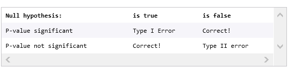

Problem with running Multiple Hypothesis Tests : At first, scientists find no link — but then they run 20 more hypothesis tests looking for a link between specific colors of jelly beans and acne. One of those tests results in a significant p-value — and the final panel of the comic shows that this one test is the only test that gets published. The comic perfectly describes how running multiple hypothesis tests and only reporting significant results is extremely problematic. This has contributed to the reproducibility crisis in statistics. At a .05 significance level, approximately 5% of hypothesis tests will result in a false positive; but if we only report those false positives, we end up with a lot of published results that can’t be replicated.

[figure not shown]

# Types of Hypothesis Tests

When trying to estimate something based on sample(s) from a larger population of interest, it is important to formulate specific questions and then quantify uncertainty about the answers.

1) Some situations involve numerical data:

- A professor expects an exam average to be roughly 75%, and wants to know if the actual scores line up with this expectation. Was the test actually too easy or too hard?
- A manager of a chain of stores wants to know if certain locations have different revenues on different days of the week. Are the revenue differences a result of natural fluctuations or a significant difference between the stores’ sales patterns?
- a PM for a website wants to compare the time spent on different versions of a homepage. Does one version make users stay on the page significantly longer?

2) Some situations involve categorical data, such as:

- A pollster wants to know if men and women have significantly different yogurt flavor preferences. Does a result where men more often answer “chocolate” as their favorite reflect a significant difference in the population?
- Do different age groups have significantly different emotional reactions to different ads?

There are several different types of hypothesis tests for the various scenarios you may encounter.

SciPy has built-in functions that perform all of these tests for us, normally using just one line of code.

For numerical data:

- **One Sample T-Tests**
- **Two Sample T-Tests**
- **ANOVA**
- **Tukey Tests**

For categorical data:

- **Binomial Tests**
- **Chi Square Test**

## Testing Sample Statistic : One Sample t-Test

**One-sample t-tests are used for comparing a sample average to a hypothetical population average**. For example, a one-sample t-test might be used to address questions such as:

- Is the average amount of time that visitors spend on a website different from 5 minutes?
- Is the average amount of money that customers spend on a purchase more than 10 USD?

Let’s imagine the fictional business BuyPie, which sends ingredients for pies to your household so that you can make them from scratch. Suppose that a product manager wants online BuyPie orders to cost around 1000 Rupees on average. In the past day, 50 people made an online purchase and the average payment per order was only 980 Rupees. Are people really spending less than 1000 Rupees on average? Or is this just the result of chance and a small sample size?

We first create a null hypothesis, which is a prediction that the observed sample comes from a population with a particular mean.  
e.g. H0 : “The average cost of a BuyPie order is 1000 Rupees”.

We determine an alternative hypothesis, which is a statement about the kind of difference we are interested in.  
e.g. HA : “The average cost of a BuyPie order is not 1000 Rupees”.

*If we form the null and alternative tests as indicated above, the test asks the following question: “Suppose that that the average cost of a BuyPie order is 1000 Rupees; what is the probability of observing a sample of 50 orders with cost as different or more different from 1000 as we did (i.e., < 980 or > 1020)?”*

We conduct the 1-Sample T-test , the result of which is a p-value.

If the p-value is less than our pre-chosen threshold (usually .05), we can reject the null hypothesis in favor of the alternative.

**SciPy has a function called ttest_1samp, which performs a 1 Sample T-Test.**

tstat, pval = ttest_1samp(example_distribution, expected_mean)  
print pval

ttest_1samp requires two inputs :

- a sample distribution (eg. the list of the 50 observed purchase prices)
- a mean to test against (eg. 1000):

**output is (1)tstat and (2)pval**

We have a small dataset called prices, representing the purchase prices of customers to BuyPie.com in the past hour.

```python
# import the packages
from scipy.stats import ttest_1samp
import numpy as np

# create the array of prices
prices = [978 , 1080 , 999 , 855 , 1105 , 961 , 899 , 1061 , 880, 1455,  505,  936,
 1024,  982,  840,  930,  829,  504,  955, 1380, 1361, 1130,  946,  973,
 1076, 1131,  810,  734, 1275,  867,  962,  865,  709, 1216,  735,  768,
  757, 1060,  715,  839,  999, 1259, 1194, 1082, 1129, 1255,  931, 1236, 921,907]

print(prices)
```

```
[978, 1080, 999, 855, 1105, 961, 899, 1061, 880, 1455, 505, 936, 1024, 982, 840, 930, 829, 504, 955, 1380, 1361, 1130, 946, 973, 1076, 1131, 810, 734, 1275, 867, 962, 865, 709, 1216, 735, 768, 757, 1060, 715, 839, 999, 1259, 1194, 1082, 1129, 1255, 931, 1236, 921, 907]
```

```python
# calculate the mean of prices
prices_mean = np.mean(prices)
print(prices_mean)
```

```
980.0
```

*Inference : Sample mean is 980 which is < population mean of 1000. Is this significant?*

**Null Hypothesis (HO): The average cost of a BuyPie order is 1000 Rupees i.e. $\mu$ = 1000** Alternate Hypothesis (HA):The average cost of a BuyPie order is not 1000 Rupees i.e. $\mu$ != 1000

```python
# Use ttest_1samp with prices to see what p-value the experiment returns
tstat, pval = ttest_1samp(prices, 1000) # pupulation mean = 1000
print(tstat)
print(pval)

# Note : ttest_1samp() requires two inputs, a sample distribution (eg. the list of the 50 observed purchase prices)
# and a mean to test against (eg. 1000)
# The ttest_1samp function uses your sample distribution to determine the sample size and estimate
# the amount of variation in the population — which are used to estimate the null distribution.
# It returns two outputs: the t-statistic (which we won’t cover in this course), and the p-value
```

```
-0.692207383420498
0.4920744804182786
```

P-values are probabilities, so they should be between 0 and 1. This p-value is the probability of observing an average purchase price less than 980 OR more than 1020 among a sample of 50 purchases.

Given that the mean purchase price in this sample was 980, which is not very far from 1000, we probably expect this p-value to be relatively large. The only reason it COULD be small (eg., <.05) is if purchase prices had very little variation (eg., they were all within a few Rupees of 980). We can see from the data print out that this is not the case. Therefore, a p-value around 0.49 makes sense!

### Assumptions of 1-Sample-t-test

The assumptions of a one-sample t-test are as follows:

1. The sample was randomly selected from the population : e.g. if you only collect data for site visitors who agree to share their personal information, this subset of visitors was not randomly selected and may differ from the larger population.
2. The individual observations were independent : e.g. if one visitor to BuyPie loves the apple pie they bought so much that they convinced their friend to buy one too, those observations were not independent.
3. The data is normally distributed without outliers OR the sample size is large (enough) : There are no set rules on what a “large enough” sample size is, but a common threshold is around 40. For sample sizes smaller than 40, and really all samples in general, it’s a good idea to make sure to plot a histogram of your data and check for outliers, multi-modal distributions (with multiple humps), or skewed distributions. If you see any of those things for a small sample, a t-test is probably not appropriate.  
   *In general, if you run an experiment that violates (or possibly violates) one of these assumptions, you can still run the test and report the results — but you should also report assumptions that were not met and acknowledge that the test results could be flawed*

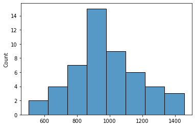

```python
# histogram of samples of 50 prices
import matplotlib.pyplot as plt
import seaborn as sns
%matplotlib inline

sns.histplot(prices);
```

*There does not seem to be any clear skewness, bi-modality, or outliers. The histogram is approximately normal.*

### Potato Yield

A farming company wants to know if a new fertilizer has improved crop yield or not.  
Historic data shows the average yield of the farm is 20 tonne per acre.  
They decide to test a new organic fertilizer on a smaller sample of farms and observe the new yield is 20.175 tonne per acre with a standard deviation of 3.02 tonne for 12 different farms.Did the new fertilizer work?  
x = [21.5, 24.5, 18.5, 17.2, 14.5, 23.2, 22.1, 20.5, 19.4, 18.1, 24.1, 18.5]

**Step 1: Define the Null Hypothesis (H0) and Alternate Hypothesis (H1)**

H0: Sample mean (x̅) = Hypothesized Population mean (µ) = 20

HA: Sample mean (x̅) != Hypothesized Population mean (µ) > 20

**The alternate hypothesis can also state that the sample mean is greater than or less than the comparison mean. However in our case we want to know if the yield is > 20 so we have HA as µ > 20**

**Step 2 : Conduct the 1-SampleT-test**  
In Python, ttest_1samp() function in the scipy package does a Two tailed test by default, and reports a signed T statistic. That means, the reported P-value will always be computed for a Two-tailed test.  
**To calculate the correct P value, you need to divide the output P-value by 2.**

```python
from scipy.stats import ttest_1samp
x =  [21.5, 24.5, 18.5, 17.2, 14.5, 23.2, 22.1, 20.5, 19.4, 18.1, 24.1, 18.5]
tscore, pvalue = ttest_1samp(x, popmean=20)
print("t Statistic: ", tscore)
print("P Value 1 tailed: ", pvalue/2)
#> t Statistic:  0.2006562773994862
#> P Value:  0.8446291893053613
#> P Value 1 Tailed = 0.4223145946526807
```

```
t Statistic:  0.2006562773994862
P Value 1 tailed:  0.4223145946526807
```

### Two Tailed, Upper Tailed or Lower Tailed

The decision of whether the computed test statistic falls in the rejection region depends on how the alternate hypothesis is defined.

We know the Null Hypothesis is H0: µD = 0. Where, µD is the difference in the means, that is sample mean minus the comparison mean.

You can also write H0 as: x̅ = µ, where x̅ is sample mean and ‘µ’ is the comparison mean.

**Case 1: If H1 : x̅ != µ,** then rejection region lies on both tails of the T-Distribution (two-tailed). This means the alternate hypothesis just states the difference in means is not equal. There is no comparison if one of the means is greater or lesser than the other.

In this case, use Two Tailed T Test , where, P value = 2*Pr(T > | t |)

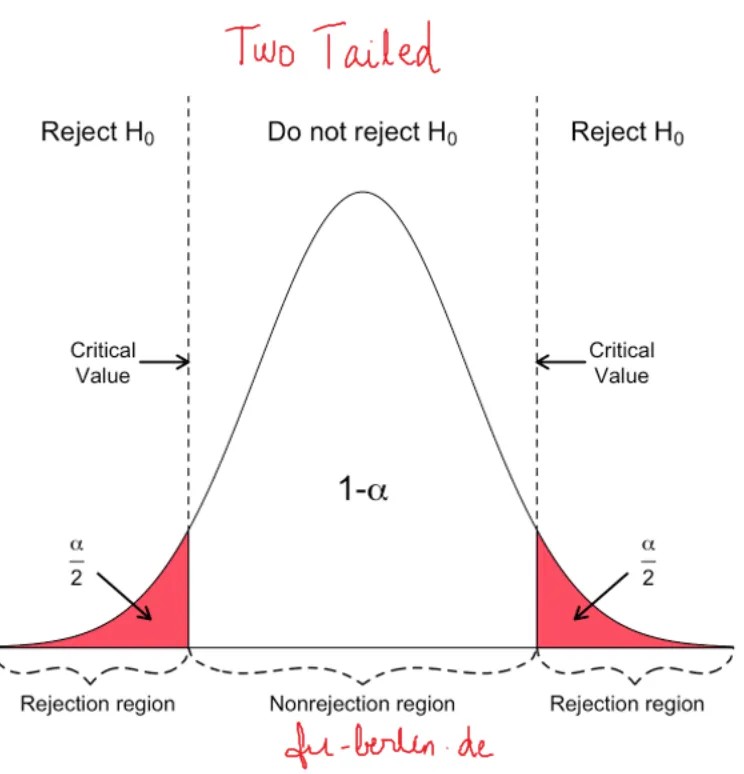

**Case 2: If H1: x̅ > µ,** then rejection region lies on upper tail of the T-Distribution (upper-tailed). If the mean of the sample of interest is greater than the comparison mean. Example: If Component A has a longer time-to-failure than Component B.

In such case, use Upper Tailed based test , where, P-value = Pr(T > t)

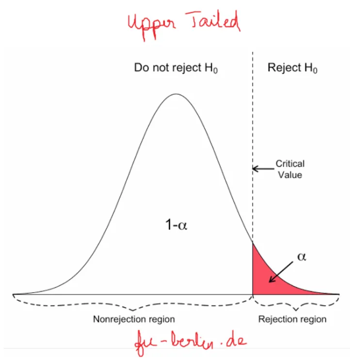

**Case 3: If H1: x̅ < µ,** then rejection region lies on lower tail of the T-Distribution (lower-tailed). If the mean of the sample of interest is lesser than the comparison mean.

In such case, use lower tailed test , where, P-value = Pr(T < t)

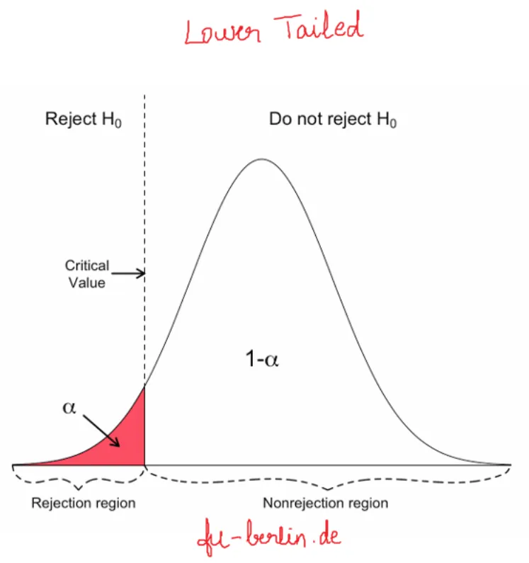

## Testing Sample Statistic : Binomial Test (categorical)

**Binomial tests are useful for comparing the frequency of some outcome in a sample to the expected probability of that outcome.** For example, if we expect 90% of ticketed passengers to show up for their flight but only 80 of 100 ticketed passengers actually show up, we could use a binomial test to understand whether 80 is significantly different from 90.

Binomial tests are similar to one-sample t-tests in that they test a sample statistic against some population-level expectation. The difference is that:

- Binomial tests are used for binary categorical data to compare a sample frequency to an expected population-level probability
- One-sample t-tests are used for quantitative data to compare a sample mean to an expected population mean.

The binomial distribution describes the number of expected “successes” in an experiment with some number of “trials”.

SciPy has a function called **binom_test()**, which performs a binomial test for you. The default alternative hypothesis for the binom_test() function is two-sided, but this can be changed using the alternative parameter (eg., alternative = 'less' will run a one-sided lower tail test).

binom_test() requires three inputs :

1. the number of observed successes
2. the number of total trials
3. an expected probability of success.

For example, with 10 flips of a fair coin (trials), the expected probability of heads is 0.5. Let’s imagine we get 2 heads (observed successes) in 10 flips The function call for this binomial test looks like :  
*from scipy import binom_test*  
*p_value = binom_test(2, n=10, p=0.5) --- # success : 2 , # trials : 10 , expected probability : 0.5*  
*print(p_value) #output: 0.109*

This tells us that IF the true probability of heads is 0.5, the probability of observing 2 or fewer heads OR 8 or more heads is 0.109 (10.9%).

We will demonstrate the application by using a binomial test to analyze data from a hypothetical online company, Live-it-LIVE.com — a website that sells all the necessary props and costumes to recreate iconic movie scenes at home!

The marketing department at Live-it-LIVE reports that, during this time of year, about **10%** of visitors to Live-it-LIVE.com make a purchase.

The monthly report shows every visitor to the site and whether or not they made a purchase. The checkout page had a small bug this month, so the business department wants to know whether the purchase rate dipped below expectation. They’ve asked us to investigate this question.

In order to run a hypothesis test to address this, we’ll first need to know two things from the data:

- The number of people who visited the website
- The number of people who made a purchase on the website

*Assuming each row of our dataset represents a unique site visitor, we can calculate the number of people who visited the website by finding the number of rows in the data frame. We can then find the number who made a purchase by using a conditional statement to add up the total number of rows where a purchase was made.*

```python
# load data
import pandas as pd
df = pd.read_csv("binom_live_it_live.csv")
df.head()
```

|  | timestamp | purchase | item |
| --- | --- | --- | --- |
| 0 | 1/17/2020 17:23 | y | cue cards - love actually |
| 1 | 1/25/2020 17:09 | n | NaN |
| 2 | 1/25/2020 5:22 | n | NaN |
| 3 | 1/18/2020 4:33 | y | t-rex - jurassic park |
| 4 | 1/24/2020 17:24 | n | NaN |

```python
#calculate and print sample_size:
sample_size = len(df)
print(sample_size)
```

```
500
```

```python
#calculate and print num_purchased:
num_purchased = np.sum(df.purchase == 'y')
print(num_purchased)
```

```
41
```

We calculated that there were 500 site visitors to live-it-LIVE.com this month and 41 of them made a purchase. In comparison, if each of the 500 visitors had a 10% chance of making a purchase, we would expect around 50 of those visitors to buy something. Is 41 different enough from 50 that we should question whether this months’ site visitors really had a 10% chance of making a purchase?

We will now use the binom_test function to run the binomial test : This will be a two-sided test for whether the observed 41 purchases among 500 visitors to Live-it-LIVE.com is far enough from the expected 10% purchase rate to convince you that the purchase rate was different from expectation this week.

```python
# import binom_test
from scipy.stats import binom_test

# calculate p_value_2sided here:
## success number = 41 i.e. 41 made a purchase
## sample size = 500 i.e. 500 site visitors
## expected probability = 0.1 i.e. 10% chance of making a purchase
p_value_2sided = binom_test(41, 500, .1)
print(p_value_2sided)
```

```
0.20456397700678308
```

```python
# calculate p_value_1sided here:
p_value_1sided = binom_test(41, 500, .1, alternative = 'less')
print(p_value_1sided)
```

```
0.1001135269756488
```

```python
# calculate p_value_1sided here:
p_value_1sided = binom_test(41, 500, .1, alternative = 'greater')
print(p_value_1sided)
```

```
0.9249107103409406
```

*Inference :*  
If each visitor has a 10% chance of making a purchase, then there is a 92% chance that, among a random sample of 500 visitors 41 or more make a purchase.Alternatively If each visitor has a 10% chance of making a purchase, then there is a 10% chance that, among a random sample of 500 visitors 41 less will make a purchase.

## Project : Heart Disease

In this project, you’ll investigate some data from a sample patients who were evaluated for heart disease at the Cleveland Clinic Foundation. The data was downloaded from the UCI Machine Learning Repository and then cleaned for analysis

**CHOLESTROL ANALYSIS**

**Task 1 : Load data**

```python
# load packages
import pandas as pd
import numpy as np

# load data
heart = pd.read_csv('heart_disease.csv')
heart.head()
```

|  | age | sex | trestbps | chol | cp | exang | fbs | thalach | heart_disease |
| --- | --- | --- | --- | --- | --- | --- | --- | --- | --- |
| 0 | 63 | male | 145 | 233 | typical angina | 0 | 1 | 150 | absence |
| 1 | 67 | male | 160 | 286 | asymptomatic | 1 | 0 | 108 | presence |
| 2 | 67 | male | 120 | 229 | asymptomatic | 1 | 0 | 129 | presence |
| 3 | 37 | male | 130 | 250 | non-anginal pain | 0 | 0 | 187 | absence |
| 4 | 41 | female | 130 | 204 | atypical angina | 0 | 0 | 172 | absence |

**Task 2 : Split into two subsets:**

1. yes_hd, which contains data for patients with heart disease
2. no_hd, which contains data for patients without heart diseas

```python
# split the data sets
yes_hd = heart[heart.heart_disease == 'presence']
no_hd = heart[heart.heart_disease == 'absence']
```

For this project, we’ll investigate the following variables:

- chol: serum cholestorol in mg/dl
- fbs: An indicator for whether fasting blood sugar is greater than 120 mg/dl (1 = true; 0 = false)

To start, we’ll investigate cholesterol levels for patients with heart disease.

**Task 3 : Use the dataset yes_hd to save cholesterol levels for patients with heart disease as a variable named chol_hd**

```python
# get cholesterol levels for patients with heart disease
chol_hd = yes_hd.chol
```

**Task 4 : In general, total cholesterol over 240 mg/dl is considered “high” (and therefore unhealthy).**  
Calculate the mean cholesterol level for patients who were diagnosed with heart disease and print it out. Is it higher than 240 mg/dl?

```python
# calculate mean cholesterol level for patients with hd
print(np.mean(chol_hd))

# mean cholestrol is higher than 240 mg/dl #
```

```
251.4748201438849
```

**Task 5 : Do people with heart disease have high cholesterol levels (greater than or equal to 240 mg/dl) on average?**

```python
## Null Hypothesis :  People with heart disease have an average cholesterol level = to 240 mg/dl
## Alternate Hypothesis : People with heart disease have an average cholesterol level > 240 mg/dl
```

```python
# scipy.stats has a limitation in that it conducts a 2-sided 1 sample t-test
# since we calculated earlier that the average cholesterol level for heart disease patients is > 240 mg/dl,
# we can calculate the p-value for the one-sided test indicated above simply by
# dividing the two-sided p-value in half
from scipy.stats import ttest_1samp
tstat, pval = ttest_1samp(chol_hd, 240) # observed values = chol_hd , population mean = 240
print(pval/2)
```

```
0.0035411033905155707
```

**Inference : p-value of 0.0035 < significance level of 0.05 hence we "reject the null hypothesis in favour of the alternate hypothesis" suggesting that heart disease patients have an average cholesterol level significantly higher than 240 mg/dl**

**Task 6 : Repeat the same process and assess if people without a heart disease have high cholestrol levels**

```python
# get cholesterol levels for patients without heart disease
chol_no_hd = no_hd.chol

# calculate mean cholesterol level for patients w/o hd
print(np.mean(chol_no_hd))

## Null Hypothesis :  People without heart disease have an average cholesterol level = to 240 mg/dl
## Alternate Hypothesis : People without heart disease have an average cholesterol level > 240 mg/dl

# compare to cut-off for high cholesterol
from scipy.stats import ttest_1samp
tstat, pval = ttest_1samp(chol_no_hd, 240)
print(pval/2)
```

```
242.640243902439
0.26397120232220506
```

**FASTING BLOOD SUGAR ANALYSIS**

**Task 1 : Let’s now return to the full dataset (saved as heart). How many patients are there in this dataset? Save the number of patients as num_patients and print it out**

```python
num_patients = len(heart) # length of dataset i.e. number of rows
print("Total Number Of Patients : " + str(num_patients))
```

```
Total Number Of Patients : 303
```

The fbs column of this dataset indicates whether or not a patient’s fasting blood sugar was greater than 120 mg/dl (1 means that their fasting blood sugar was greater than 120 mg/dl; 0 means it was less than or equal to 120 mg/dl).

**Task 2 : Calculate the number of patients with fasting blood sugar greater than 120. Save this number as num_highfbs_patients and print it out**

```python
# calculate number of patients with fbs>120
num_highfbs_patients = np.sum(heart.fbs) # sum of column with fbs values = 1
print("Number of Patients with High Fasting Blood Sugar : " + str(num_highfbs_patients))
```

```
Number of Patients with High Fasting Blood Sugar : 45
```

By some estimates, about 8% of the U.S. population had diabetes (diagnosed or undiagnosed) in 1988 when this data was collected. While there are multiple tests that contribute to a diabetes diagnosis, fasting blood sugar levels greater than 120 mg/dl can be indicative of diabetes (or at least, pre-diabetes).

**Task 3 : If the sample data were representative of the population, approximately how many people would you expect to have diabetes? Calculate and print out this number.Is this value similar to the number of patients with a resting blood sugar above 120 mg/dl — or different?**

```python
# calculate 8% of sample size
print(0.08*num_patients) #

# We want to calculate 8% of the sample size (which is 303).
# Therefore, we should multiply 0.08*303.
```

```
24.240000000000002
```

*This comes out to approximately 24 patients, which is almost half the number with fbs > 120 in the sample (45).Implying from a population of 303 patients we expect 24 to have "High Fasting Blood Sugar" which is ~50% of the actual recorded*

**Task 4 : Does this sample come from a population in which the rate of fbs > 120 mg/dl is equal to 8%?Import the function from scipy.stats that you can use to test the following null and alternative hypotheses**

- Null Hypothesis : This sample was drawn from a population where **8% of people** have fasting blood sugar > 120
- Alternative: This sample was drawn from a population where **more than 8% of people** have fasting blood sugar > 120
- This hypothesis is suggestive of a "Binomial test"
- Parameters for the Binomial Test should be set at success = # of patients with high fsb (45) , sample size = total patients (303) , expected probability 8% , alternate = 'greater'

```python
# The binom_test() function takes four parameters (in order)
# The observed number of “successes” (in this case, the number of people in the sample
# who had fasting blood sugar greater than 120 mg/dl)
# The number of “trials” (in this case, the number of patients)
# The null probability of “success” (in this case, 0.08)
# The alternative parameter, which indicates the alternative hypothesis for the test
#(eg.,'two-sided' 'greater' or 'less') in our case 'greater'

# run binomial test
from scipy.stats import binom_test
pval = binom_test(num_highfbs_patients, num_patients, .08, alternative='greater')
print(pval)
```

```
4.689471951449078e-05
```

**Interpretation : p-value of 4.6e-05 which is < than 0.05, implying we "reject the null hypothesis" in favor of the alternate indicating that this sample likely comes from a population where more than 8% of people have fbs > 120 mg/dl.**

## Two Sample (independent groups) t-Test : Variances between 2 groups

Suppose that a company has recently updated their website to make it more colorful and inviting. The company wants to know whether the new design is resulting in visitors staying on the site for a longer period of time. A sample of 100 visitors who saw the old design spent an average of 25 minutes on the site. A second sample of 100 visitors who saw the new version spent an average of 28 minutes on the site. Did the average time spent per visitor vary across groups? Or is this difference attributable to random chance?

One way of testing whether this difference is significant is by using a **2 Sample T-Test**.  
**A 2 Sample T-Test compares two sets of numerical data.**

**Null hypothesis H0 : The two observed samples come from populations with the same mean.**

In the example above, this means: if we could observe all site visitors in two alternate universes (one where they see each version of the site), the average visiting times in these universes would be equal.

**Alternative hypothesis HA : The two observed samples come from populations with different means.**

In the example above, this would mean that the average visiting times in our two alternate universes are actually different, hence why we observed a difference in our samples.

We can use SciPy’s **ttest_ind** function to perform a 2 Sample T-Test.

It takes the two samples as inputs and returns the t-statistic and a p-value, which we can use to assess the **Probability of an observed difference happening by chance if the null hypothesis were true.**

**Note : Independant sample t-test implies the "test variable is continuous' and 'group variable is binary'**

**Example**  
A company randomly sampled 100 site visitors. They showed the old version of their website to half of their sample and the new version to the other half. The amount of time (in minutes) that each visitor spent on the website was recorded.An overlaid histogram showing the amount of time spent on the website by visitors to the new and old versions was plotted.Based on this picture, do you think there is a significant association between the version of the website a visitor saw and how long they spent on the site?

```python
import pandas as pd
import numpy as np
import matplotlib.pyplot as plt
import seaborn as sns
%matplotlib inline
sns.set()
from scipy.stats import ttest_ind
```

```python
data = pd.read_csv('version_time.csv')
data.head(2)
```

|  | time_minutes | version |
| --- | --- | --- |
| 0 | 11.92 | new |
| 1 | 12.90 | old |

```python
#separate out times for  two versions
old = data.time_minutes[data.version=='old']
new = data.time_minutes[data.version=='new']
```

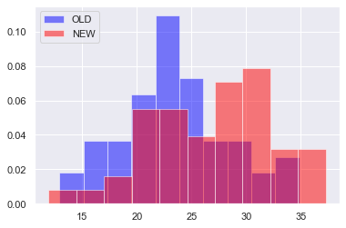

```python
#plot the overlayed histograms
fig, ax = plt.subplots(1, 1)
ax.hist(old, alpha=0.5, label='OLD' , density = True , color="blue")
ax.hist(new, alpha=0.5, label='NEW' , density = True , color = "red")
ax.legend(loc='upper left')
plt.show();
```

There is a fair amount of overlap, but it does seem like visitors to the new website are spending slightly more time on the site (the red distribution is shifted slightly to the right of the blue distribution).

```python
# Run a two-sample t-test comparing these groups
# Null Hypothesis (H0) : Mean Time Spent on old and new websites are the same
# Alternate Hypothesis (HA) : Mean Time Spent on old and new websites are different
tstat, pval = ttest_ind(old, new)
print(pval)
```

```
0.0020408264429904
```

*Inference : p-value 0.002 < 0.05 which is significant implying we "reject the null" in "favor of the alternate" and infer that there is a significant difference in time spent between old and new websites*

## Paired Sample (Same Group : Before and After)

The paired sample t-test also known as the **dependent sample t-test** or **paired t-test** , compares two averages (means) and will give us information if the difference between these two averages are zero.  
In a paired sample t-test, each participant is measured twice, which results in pairs of observations.

For example, if clinical psychologists want to test whether a treatment for depression will change the quality of life, they might set up an experiment. In this experiment, they will collect information about the participants’ quality of life before the intervention (i.e., the treatment and after. They are conducting a pre- and post-test study. In the pre-test the average quality of life might be 3, while in the post-test the average quality of life might be 5. Numerically, we could think that the treatment is working. However, it could be due to a fluke and, in order to test this, the clinical researchers can use the paired sample t-test.

**Hypotheses** : When performing dependent sample t-tests you typically have the following two hypotheses:  
**Null hypotheses H0: The true mean difference is equal to zero (between the observations)**  
**Alternative hypotheses HA: the true mean difference is not equal to zero (two-tailed)**

### Assumptions for Paired Sample t-Test

- The dependent variable (DV) must be continuous which is measured on an interval or ratio scale
- The DV should be approximately normally distributed *(The paired sample t-test is robust to this violation. If there is a violation of normality, as long as it’s not in a major violation the test results can be considered valid)*
- The DV should not contain any significant outliers

*If any of these assumptions are violated, a different test should be used. An alternative to the paired sample t-test is the Wilcoxon signed-rank Test.*

**Example:**  
The data set is fictitious and contains blood pressure readings before & after an intervention. These are variables “bp_before” and “bp_after”.

```python
# load the data
import pandas as pd

df = pd.read_csv("blood_pressure.csv")

df[['bp_before','bp_after']].describe()
```

|  | bp_before | bp_after |
| --- | --- | --- |
| count | 120.000000 | 120.000000 |
| mean | 156.450000 | 151.358333 |
| std | 11.389845 | 14.177622 |
| min | 138.000000 | 125.000000 |
| 25% | 147.000000 | 140.750000 |
| 50% | 154.500000 | 149.500000 |
| 75% | 164.000000 | 161.000000 |
| max | 185.000000 | 185.000000 |

```python
df.head(2)
```

|  | patient | sex | agegrp | bp_before | bp_after |
| --- | --- | --- | --- | --- | --- |
| 0 | 1 | Male | 30-45 | 143 | 153 |
| 1 | 2 | Male | 30-45 | 163 | 170 |

**Checking for outliers**

```python
# import packages
import matplotlib.pyplot as plt
import seaborn as sns
%matplotlib inline
```

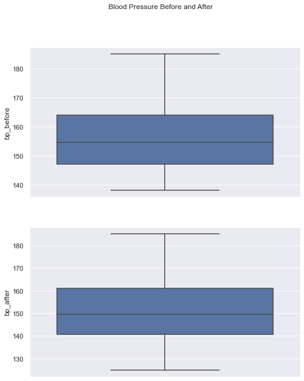

```python
fig, axes = plt.subplots(2, 1 ,figsize=(8, 10))
fig.suptitle('Blood Pressure Before and After')
sns.boxplot(ax=axes[0], data=df, y='bp_before')
sns.boxplot(ax=axes[1], data=df,  y='bp_after')
plt.show();
```

There doesn’t appear to be any significant outliers in the variables

**Check for Normality**

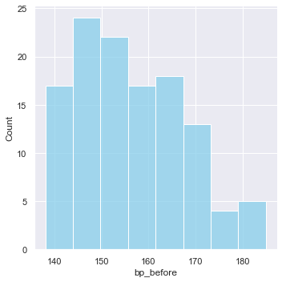

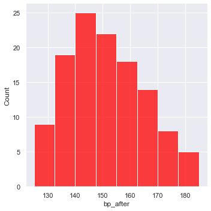

```python
sns.displot(df["bp_before"] , color="skyblue", label="Before")
sns.displot( df["bp_after"] , color="red", label="After")
plt.show();
```

The histograms of our data does not seem to be normally distributed. There looks to be some skew.  
Let’s test this statistically to see if the data is normally distributed. To test this, one can use the Shapiro-Wilk test for normality

```python
from scipy import stats

print(stats.shapiro(df['bp_before']))
print(stats.shapiro(df['bp_after']))
```

```
ShapiroResult(statistic=0.9547787308692932, pvalue=0.0004928423441015184)
ShapiroResult(statistic=0.9740639328956604, pvalue=0.020227791741490364)
```

Both of the variables violate the assumption of normality by a large amount. Therefore, one should use a different test to analyze this data. As mentioned early, an appropriate alternative to use would be the Wilcoxon signed-rank Test. However, for demonstration purposes, I shall continue with using the paired sample t-test. Note, that the findings from this analysis should not be considered valid due to the large violation of the assumption about normality

**Conducting the t-Test**  
To conduct the paired sample t-test, one needs to use the stats.ttest_rel() method

```python
stats.ttest_rel(df['bp_before'], df['bp_after'])
```

```
Ttest_relResult(statistic=3.3371870510833657, pvalue=0.0011297914644840823)
```

The findings are statistically significant! One can reject the null hypothesis in support of the alternative.

**Interpretation** A paired sample t-test was used to analyze the blood pressure before and after the intervention to test if the intervention had a significant affect on the blood pressure.  
The blood pressure before the intervention was higher (156.45 ± 11.39 units) compared to the blood pressure post intervention (151.36 ± 14.18 units.  
There was a statistically significant decrease in blood pressure (t(119)=3.34, p= 0.0011) of 5.09 units.

## Analysis of Variance (ANOVA)

ANOVA stands for "Analysis of Variance" and is an omnibus test, meaning it tests for a difference overall between all groups. The one-way ANOVA, also referred to as one factor ANOVA, is a parametric test used to test for a statistically significant difference of an outcome between 3 or more groups. Since it is an omnibus test, it tests for a difference overall, i.e. at least one of the groups is statistically significantly different than the others. However, if the ANOVA is significant one cannot tell which group is different. In order to tell which group is different, one has to conduct planned or post-hoc comparisons. As with all parametric tests, there are certain conditions that need to be met in order for the test results to be considered reliable.

The reason why it's called an one-way or one factor ANOVA even though there are 3 or more groups being tested is because those groups are under one categorical variable, such as race or education level, and the name is referring to the number of variables in the analysis and not the number of groups. If there are two variables being compared it would technically be called a two-way, or two factor, ANOVA if both variables are categorical, or it could be called an ANCOVA if the 2nd variable is continuous. The "C" doesn't stand for continuous, it stands for covariate.

When working from the ANOVA framework, independent variables are sometimes referred to as factors and the number of groups within each variable are called levels, i.e. one variable with 3 categories could be referred to as a factor with 3 levels.

**ANOVA tests the null hypothesis that all of the samples come from populations with the same mean.If we reject the null hypothesis with ANOVA, we’re saying that at least one pair of populations (from which the samples were drawn) have different means; however, we cannot determine exactly which pair(s)**

We can use the SciPy function f_oneway to perform ANOVA on multiple datasets. **f_oneway** takes in each dataset as a different input and returns the F-statistic and the p-value.

For example, if we were comparing scores on a videogame between math majors, writing majors, and psychology majors, we could run an ANOVA test with this line: **fstat, pval = f_oneway(scores_mathematicians, scores_writers, scores_psychologists)**

The null hypothesis, in this case, is that all three populations have the same mean score on this videogame.  
If we reject this null hypothesis (if we get a p-value less than 0.05), we can say that we are reasonably confident that at least one pair of populations is significantly different. After using only ANOVA, we can’t make any conclusions on which two populations have a significant difference.

Hypothesis :  
**Null Hypothesis (H0) : x1=x2=x3=...xn {All populations have the same mean)**  
**Alternate Hypothesis (HA) : At-least one of the groups means differ**

The test statistic is the F-statistic and compares the mean square between samples (MSb)to the mean square within sample (MSw). This F-statistic can be calculated using the following formula: F = MSb/MSw

One rejects the the null hypothesis,if the computed F-static is greater than the critical F-statistic.The critical F-statistic is determined by the degrees of freedom and alpha value.  
**Reject H0 if calculated F-Statistic > critical F-Statistic**

**Example:** Suppose that we own a chain of stores that sell ants, called VeryAnts. There are three different locations: A, B, and C. We want to know whether customers are spending a significantly different amount per order at any of the locations.In this case Dependent Variable(DV) is the amount spent and Independent Variable (IV) are the 3 store locatiols "A-B-C" that are categorical.

**Load data**

```python
# load the data
veryants = pd.read_csv('very_ants.csv')
veryants.head(5).T
```

|  | 0 | 1 | 2 | 3 | 4 |
| --- | --- | --- | --- | --- | --- |
| Sale | 73.57 | 38.37 | 49.36 | 61.96 | 38.74 |
| Store | A | A | A | A | A |

```python
# store data separately
a = veryants.Sale[veryants.Store == 'A']
b = veryants.Sale[veryants.Store == 'B']
c = veryants.Sale[veryants.Store == 'C']
```

**Run one-way ANOVA**

```python
# run ANOVA
from scipy.stats import f_oneway
Fstat, pval = f_oneway(a, b, c)
print(pval)
```

```
0.00015355234908845413
```

*Inference : At a significance level of 0.05 , we "Reject the Null Hypothesis" in favor of the Alternate Hypothesis and infer that at least one pair of stores have significantly different average sales*

### One Way Anova with STATSMODELS

This method conducts a one-way ANOVA in two steps:  
Step 1 : Fit the model using an estimation method (The default estimation method in most statistical software packages is ordinary least squares OLS , one of many types of estimation methods that aim to provide estimates of the parameter (mean, propertion, etc.) being tested)  
**model = ols("outcome_variable ~ C(independent_variable)", data= data_frame).fit()**  
Step 2 : Pass fitted model into ANOVA method to produce ANOVA table(argument "typ" in the anova_lm method, this determines how the sum of squares is calculated)  
**aov_table = sm.stats.anova_lm(model, typ=2)**

Note : In the case of an ANOVA, the independent variable will be categorical

```python
# import the desired libraries
import statsmodels.api as sm
from statsmodels.formula.api import ols

# fit the model on data with "Sale" as DV and "Store" as IV
model = ols('Sale ~ Store', data=veryants).fit()

# Produce the ANOVA Table
aov_table = sm.stats.anova_lm(model, typ=2)
aov_table
```

|  | sum_sq | df | F | PR(>F) |
| --- | --- | --- | --- | --- |
| Store | 3984.777478 | 2.0 | 8.956266 | 0.000154 |
| Residual | 99438.514719 | 447.0 | NaN | NaN |

## Tukey's Range Test (ANOVA post-Hoc-Testing)

Let’s say that we have performed an ANOVA to compare sales at the three VeryAnts stores. We calculated a p-value less than 0.05 and concluded that there is a significant difference between at least one pair of stores.  
Now, we want to find out which pair of stores are different. This is where Tukey’s range test comes in handy!  
**Tukey Honestly Significant Difference (HSD)**  
In Python, we can perform Tukey’s range test using the statsmodels function pairwise_tukeyhsd().By conducting post-hoc tests or planned comparisons it allows one to see which group(s) significantly differ from each other.

Tukey’s range test is similar to running multiple separate 2-sample t-tests, except that it runs all of these tests simultaneously in order to preserve the type I error rate. The function output is a table, with one row per pair-wise comparison. For every comparison where reject is True, we “reject the null hypothesis” and conclude there is a significant difference between those two groups.

Let us run Tukey’s range test with a type I error rate of 0.05 to determine whether average sales are different at any pair of two stores

```python
from statsmodels.stats.multicomp import pairwise_tukeyhsd

# run tukey's test with significance level of 0.05
tukey_results = pairwise_tukeyhsd(veryants.Sale, veryants.Store, 0.05)
print(tukey_results)
```

```
Multiple Comparison of Means - Tukey HSD, FWER=0.05
====================================================
group1 group2 meandiff p-adj   lower   upper  reject
----------------------------------------------------
     A      B   7.2763  0.001  3.2263 11.3264   True
     A      C    4.011 0.0529 -0.0391  8.0611  False
     B      C  -3.2653  0.141 -7.3154  0.7847  False
----------------------------------------------------
```

Now to make sense of the table.

1. At the top the table testing information is provided FWER which is the familywise error rate, i.e. what is being set to and controlled at
2. group1 and group2 columns are the groups being compared
3. meandiff is the difference between the group means
4. p-adj is the corrected p-value which takes into account the multiple comparisons being conducted
5. lower is the lower band of the confidence interval at the 95% level since LOS = 0.05.
6. upper is the upper band of the confidence intervalat the 95% level since LOS = 0.05.
7. reject is the decision rule based on the corrected p-value

## Assumptions of T-Tests, ANOVA, and Tukey

Before we use a two sample t-test, ANOVA, or Tukey’s range test, we need to be sure that the following assumptions are true:

1. **The observations should be independently randomly sampled from the population**  
   Suppose the population we are interested in is all visitors to a website. Random sampling will help ensure that our sample is representative of the population we care about.
2. **The standard deviations of the groups should be equal**  
   For example, if we’re comparing time spent on a website for two versions of a homepage, we first want to make sure that the standard deviation of time spent on version 1 is roughly equal to the standard deviation of time spent on version 2. To check this assumption, it is normally sufficient to divide one standard deviation by the other and see if the ratio is “close” to 1. Generally, a ratio between 0.9 and 1.1 should suffice. That said, there is also a way to run a 2-sample t-test without assuming equal standard deviations — for example, by setting the equal_var parameter in the scipy.stats.ttest_ind() function equal to False. Running the test in this way has some disadvantages (it essentially makes it harder to reject the null hypothesis even when there is a true difference between groups), so it’s important to check for equal standard deviations before running the test.
3. **The data should be nearly normally distributed**  
   Data analysts in the real world often still perform these tests on data that are not normally distributed. This is usually not a problem if sample size is large, but it depends on how non-normal the data is. In general, the bigger the sample size, the safer we are.
4. **The groups created by the categorical variable must be independent**  
   Examples where the groups are not independent:  
   *Number of goals scored per soccer player before, during, and after undergoing a rigorous training regimen (not independent because the same players are measured in each category)*  
   *Years of schooling completed by a group of adults compared to their parents (not independent because kids and their parents can influence one another)*

## Chi-Squared Test of Independence (Categorical-Association)

If we want to understand whether the outcomes of two categorical variables are associated, we can use a Chi-Square test. It is useful in situations like:

- An A/B test where half of users were shown a green submit button and the other half were shown a purple submit button. Was one group more likely to click the submit button?
- People under and over age 40 were given a survey asking “Which of the following three products is your favorite?” Did these age groups have significantly different preferences? The Chi-Squared test of independence is used to test for a relationship between two categorical variables.

The Chi-Squared test is a statistical hypothesis test that assumes (the null hypothesis) that the **observed frequencies** for a categorical variable match the **expected frequencies** for the categorical variable. The Chi-Squared test does this for a contingency table, first calculating the expected frequencies for the groups, then determining whether the division of the groups, called the observed frequencies, matches the expected frequencies.

The result of the test is a **test statistic that has a chi-squared distribution** and can be interpreted to reject or fail to reject the assumption or null hypothesis that the observed and expected frequencies are the same.

When observed frequency is far from the expected frequency, the corresponding term in the sum is large; when the two are close, this term is small. **Large values of Chi-square indicate that observed and expected frequencies are far apart. Small values of Chi-square mean the opposite: observed are close to expected.**

**“The variables are considered independent if the observed and expected frequencies are similar, that the levels of the variables do not interact, are not dependent.“**

In SciPy, we can use the function chi2_contingency() to perform a Chi-Square test. The input to chi2_contingency is a contingency table, which can be created using the pandas crosstab() function as follows:  
.......................................................  
*create table:*  
import pandas as pd  
table = pd.crosstab(variable_1, variable_2)

*run the test:*  
from scipy.stats import chi2_contingency  
chi2, pval, dof, expected = chi2_contingency(table)  
.........................................................

The input to chi2_contingency is a contingency table where:

- The columns are each a different condition, such as Interface A vs. Interface B
- The rows represent different outcomes, like “Clicked a Link” vs. “Didn’t Click” This table can have as many rows and columns as you need.

Let’s return to the question of whether gender is associated with the probability of a website visitor making a purchase.  
*The null hypothesis is that there’s no association between the variables (eg. males, females, and non-binary people are all equally likely to make a purchase on the website, so gender and purchase-status are not associated).*  
If the p-value is below our chosen threshold (often 0.05), we reject the null hypothesis and can conclude there is a statistically significant association between the two variables (eg. men, women, and non-binary people appear to have different probabilities of making a purchase, so gender is associated with purchase-status).

**Example 1**  
The management at the VeryAnts ant store wants to know if their two most popular species of ants, the Leaf Cutter and the Harvester, vary in popularity between 1st, 2nd, and 3rd graders.

```python
# load data and import stats package
import pandas as pd
from scipy.stats import chi2_contingency

# read in and print data
ants = pd.read_csv("ants_grade.csv")
print(ants.head())
```

```
  Grade          Ant
0   1st    harvester
1   2nd    harvester
2   2nd  leaf cutter
3   1st    harvester
4   3rd  leaf cutter
```

```python
# create contingency table
table = pd.crosstab(ants.Grade, ants.Ant)
table
```

| Ant Grade | harvester | leaf cutter |
| --- | --- | --- |
| 1st | 28 | 8 |
| 2nd | 31 | 5 |
| 3rd | 23 | 13 |

```python
# run Chi-Square test and print p-value
chi2, pval, dof, expected = chi2_contingency(table)
print(pval)
```

```
0.08356116834982279
```

**p-value > Level of Significance 0.05 implying we "Fail to reject the Null Hypothesis" in favor of the Alternate and infer that there is not evidence that the two most popular species of ants, the Leaf Cutter and the Harvester, vary in popularity between 1st, 2nd, and 3rd graders.**

**Example 2 : Gender and Online Learning**  
A sample of 314 Penn State students was asked if they have ever taken an online course.Their genders were also recorded. The contingency table below was constructed.Use a chi-square test of independence to determine if there is a relationship between gender and whether or not someone has taken an online course

**Null Hypothesis (H0) : There is not a relationship between gender and whether or not someone has taken an online course (they are independent)**  
**Alternate Hypothesis (HA) : There is a relationship between gender and whether or not someone has taken an online course (they are dependent)**

```python
from scipy.stats import chi2_contingency

# Contingency table
#         on-line-Yes |  on-line-No
# ----+------------------+------------
# Men    | 43         |  63
# Women  | 95         |  113

# construct the contingency table
Table = [[43, 63],
     [95, 113]]

# run the test
chi2, pval, dof, expected = chi2_contingency(Table)
print("p-value :" + str(pval))
print("chi-squared : " + str(chi2))
```

```
p-value :0.45808296868304743
chi-squared : 0.5505746960817084
```

**p-value > Level of Significance 0.05 implying we "Fail to reject the Null Hypothesis" and infer that there is no relationship between gender and whether or not someone has taken an online course**

## Assumptions of a Chi-Square Test

Before we use a Chi-Square test, we need to be sure that the following things are true:

1. **The observations should be independently randomly sampled from the population**  
   This is also true of 2-sample t-tests, ANOVA, and Tukey. The purpose of this assumption is to ensure that the sample is representative of the population of interest.
2. **The categories of both variables must be mutually exclusive**  
   In other words, individual observations should only fall into one category per variable. This means that categorical variables like “college major”, where students can have multiple different college majors, would not be appropriate for a Chi-Square test.
3. **The groups should be independent**  
   Similar to 2-sample t-tests, ANOVA, and Tukey, a Chi-Square test also shouldn’t be used if either of the categorical variables splits observations into groups that can influence one another. For example, a Chi-Square test would not be appropriate if one of the variables represents three different time points.

**Example :Covid19**  
Researchers are running a study to test a new vaccine for Covid-19 in adults. A sample of 1000 adults (you can assume that they are randomly sampled adults, or at least representative of the population) are randomly split into two groups: half get a vaccine, while the other half get a placebo. Everyone is monitored for six months to see if they develop symptoms of Covid-19. The first few rows of the resulting dataset looks like this:

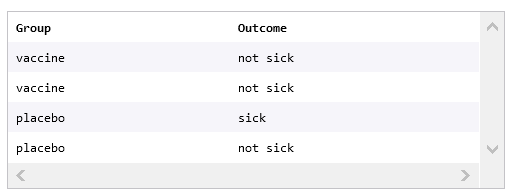

*Question : The researchers want to use this data to determine whether their vaccine will be effective at preventing illness in the general population of adults (eg., is whether or not someone got a vaccine associated with whether or not they got sick?).Is a Chi-Square test appropriate to address this question?*

*Answer : Yes. This research question addresses an association between two categorical variables. The sample is representative of the population, the categories are mutually exclusive (each person gets a placebo or vaccine but not both; each person gets sick or doesn’t get sick), and the groups are independent*

**Example :Yoga**  
Researchers are interested in studying the effect of a 10 minute yoga regimen on self-reported mood in adults. In order to test this, a representative sample of 1000 adults are asked to complete a survey where they rate their current happiness level as “very low”, “low”, “neutral”, “high”, or “very high”. Each person then completes a 10 minute yoga regimen, then responds to the same survey once again. The first few rows of data from this study look like this:

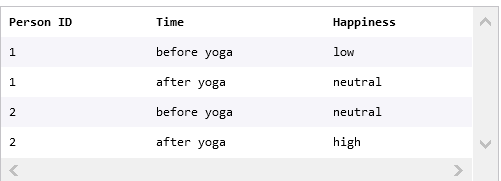

*Question : The researchers want to know if 10 minutes of yoga can help improve self-reported mood for adults in the general population (eg., is whether or not someone has just completed 10 minutes of yoga associated with their self-reported happiness level?).Is a Chi-Square test appropriate to address this question?*

*Answer : No. Note that one of the categorical variables has to do with time (before or after yoga). This variable splits observations into groups that are not independent: someone’s happiness level before yoga can clearly influence their happiness level after yoga*

**CHEATSHEET SUMMARIZING TESTS FOR ASSOCIATION**

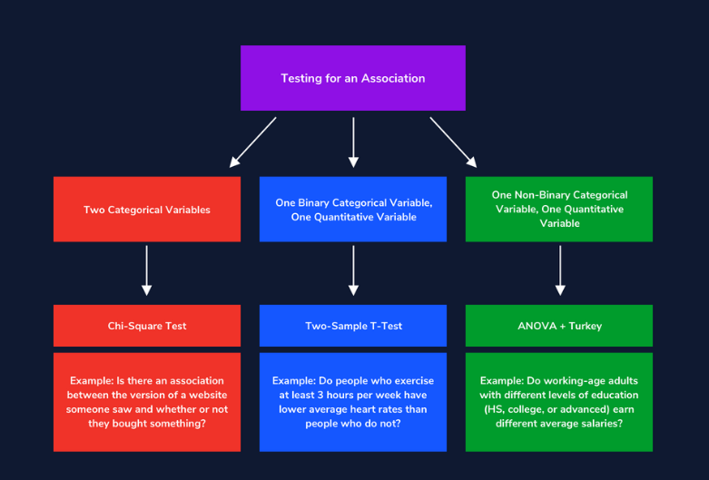

# Project : Heart Disease Research

In this project, we will investigate some data from a sample patients who were evaluated for heart disease at the Cleveland Clinic Foundation. The data was downloaded from the UCI Machine Learning Repository and then cleaned for analysis.The dataset contains the following variables:

- age: age in years
- sex: sex assigned at birth; 'male' or 'female'
- trestbps: resting blood pressure in mm Hg
- chol: serum cholesterol in mg/dl
- cp: chest pain type ('typical angina', 'atypical angina', 'non-anginal pain', or 'asymptomatic')
- exang: whether the patient experiences exercise-induced angina (1: yes; 0: no)
- fbs: whether the patient’s fasting blood sugar is >120 mg/dl (1: yes; 0: no)
- thalach: maximum heart rate achieved in exercise test
- heart_disease: whether the patient is found to have heart disease ('presence': diagnosed with heart disease; 'absence': no heart disease)

**Task 1 : Load Data and Review**

```python
# import packages
import pandas as pd
import numpy as np
import matplotlib.pyplot as plt
import seaborn as sns
%matplotlib inline
sns.set()
```

```python
# load the data and review 1st 5 rows
heartdf = pd.read_csv('heart_disease.csv')
heartdf.head()
```

|  | age | sex | trestbps | chol | cp | exang | fbs | thalach | heart_disease |
| --- | --- | --- | --- | --- | --- | --- | --- | --- | --- |
| 0 | 63 | male | 145 | 233 | typical angina | 0 | 1 | 150 | absence |
| 1 | 67 | male | 160 | 286 | asymptomatic | 1 | 0 | 108 | presence |
| 2 | 67 | male | 120 | 229 | asymptomatic | 1 | 0 | 129 | presence |
| 3 | 37 | male | 130 | 250 | non-anginal pain | 0 | 0 | 187 | absence |
| 4 | 41 | female | 130 | 204 | atypical angina | 0 | 0 | 172 | absence |

```python
heartdf.info()
```

```
<class 'pandas.core.frame.DataFrame'>
RangeIndex: 303 entries, 0 to 302
Data columns (total 9 columns):
 #   Column         Non-Null Count  Dtype
---  ------         --------------  -----
 0   age            303 non-null    int64
 1   sex            303 non-null    object
 2   trestbps       303 non-null    int64
 3   chol           303 non-null    int64
 4   cp             303 non-null    object
 5   exang          303 non-null    int64
 6   fbs            303 non-null    int64
 7   thalach        303 non-null    int64
 8   heart_disease  303 non-null    object
dtypes: int64(6), object(3)
memory usage: 21.4+ KB
```

```python
heartdf.describe(include='all')
```

|  | age | sex | trestbps | chol | cp | exang | fbs | thalach | heart_disease |
| --- | --- | --- | --- | --- | --- | --- | --- | --- | --- |
| count | 303.000000 | 303 | 303.000000 | 303.000000 | 303 | 303.000000 | 303.000000 | 303.000000 | 303 |
| unique | NaN | 2 | NaN | NaN | 4 | NaN | NaN | NaN | 2 |
| top | NaN | male | NaN | NaN | asymptomatic | NaN | NaN | NaN | absence |
| freq | NaN | 206 | NaN | NaN | 144 | NaN | NaN | NaN | 164 |
| mean | 54.438944 | NaN | 131.689769 | 246.693069 | NaN | 0.326733 | 0.148515 | 149.607261 | NaN |
| std | 9.038662 | NaN | 17.599748 | 51.776918 | NaN | 0.469794 | 0.356198 | 22.875003 | NaN |
| min | 29.000000 | NaN | 94.000000 | 126.000000 | NaN | 0.000000 | 0.000000 | 71.000000 | NaN |
| 25% | 48.000000 | NaN | 120.000000 | 211.000000 | NaN | 0.000000 | 0.000000 | 133.500000 | NaN |
| 50% | 56.000000 | NaN | 130.000000 | 241.000000 | NaN | 0.000000 | 0.000000 | 153.000000 | NaN |
| 75% | 61.000000 | NaN | 140.000000 | 275.000000 | NaN | 1.000000 | 0.000000 | 166.000000 | NaN |
| max | 77.000000 | NaN | 200.000000 | 564.000000 | NaN | 1.000000 | 1.000000 | 202.000000 | NaN |

## Predictors of Heart Disease

**Task 1** Each of the patients in this dataset underwent an exercise test, during which their heart rate was monitored. For each patient, thalach gives us the highest heart rate that the patient achieved during this test.

Is thalach associated with whether or not a patient will ultimately be diagnosed with heart disease?  
Use sns.boxplot() to plot side by side box plots of thalach for patients who were and were not diagnosed with heart disease (indicated by the heart_disease variable).  
Do you think there is a relationship between these variables?

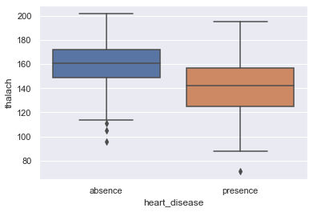

```python
# box plot of `thalach` based on heart disease
sns.boxplot(x=heartdf.heart_disease, y=heartdf.thalach)
plt.show();
```

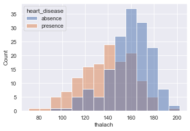

```python
# histogram of `thalach` based on heart disease
sns.histplot(data = heartdf , x='thalach' , hue = 'heart_disease')
plt.show();
```

**Task 2 :**  
Calculate and print the difference in mean thalach for patients diagnosed with heart disease compared to patients without heart disease.Then do the same for the median difference.

```python
# save `thalach` for hd patients and non-hd patients
thalach_hd = heartdf.thalach[heartdf.heart_disease == 'presence']
thalach_no_hd = heartdf.thalach[heartdf.heart_disease == 'absence']

# calculate and print mean difference
mean_diff = np.mean(thalach_no_hd) - np.mean(thalach_hd)
print('`thalach` mean Difference: ', mean_diff)

# calculate and print median difference
med_diff = np.median(thalach_no_hd) - np.median(thalach_hd)
print('`thalach` median Difference: ', med_diff)
```

```
`thalach` mean Difference:  19.11905597473242
`thalach` median Difference:  19.0
```

*Inference : Median and Mean Differences are commparable*

**Task 3 :**  
We’d like to find out if the average thalach of a heart disease patient is significantly different from the average thalach for a person without heart disease. We are comparing the means of two groups with a Hypothesis as follows :  
*Null: The average thalach for a person with heart disease is equal to the average thalach for a person without heart disease.*  
*Alternative: The average thalach for a person with heart disease is NOT equal to the average thalach for a person without heart disease*

Since we are comparing a continuous outcome between two groups i.e. patients with and without heart disease , we will run "Independent Sample t-Test".Using a significance threshold of 0.05, we will assess if there is a significant difference in average thalach for people with heart disease compared to people with no heart disease.

```python
# run two-sample t-test
from scipy.stats import ttest_ind
tstat, pval = ttest_ind(thalach_hd, thalach_no_hd)
print('p-value for `thalach` two-sample t-test: ', pval)
```

```
p-value for `thalach` two-sample t-test:  3.456964908430172e-14
```

*Inference : p-value of ~0 is less than 0.05, so we “reject the null hypothesis” and conclude that there is a significant difference in heart rates achieved during exercise for people with heart disease compared to people without heart disease*

**Task 4 : We’d like to find out if the average age , resting blood pressure & serum cholesterol of a heart disease patient are significantly different from that for a person without heart disease**

**Resting Blood Pressure v/s Heart Disease**

```python
# mean resting blood pressure by heart disease
resting_bp_mean = heartdf.groupby("heart_disease")["trestbps"].mean()
print(resting_bp_mean)
mean_rbp_diff = np.round((resting_bp_mean[1]-resting_bp_mean[0]),2)
print("Difference in mean resting blood pressure :" + str(mean_rbp_diff))
```

```
heart_disease
absence     129.250000
presence    134.568345
Name: trestbps, dtype: float64
Difference in mean resting blood pressure :5.32
```

```python
# median resting blood pressure by heart disease
resting_bp_median = heartdf.groupby("heart_disease")["trestbps"].median()
print(resting_bp_median)
median_rbp_diff = np.round((resting_bp_median[1]-resting_bp_median[0]),2)
print("Difference in median resting blood pressure :" + str(median_rbp_diff))
```

```
heart_disease
absence     130
presence    130
Name: trestbps, dtype: int64
Difference in median resting blood pressure :0
```

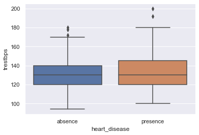

```python
# box plot of `trestbps` based on heart disease
sns.boxplot(x=heartdf.heart_disease, y=heartdf.trestbps)
plt.show();
```

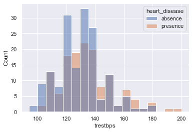

```python
# histogram of `trestbps` based on heart disease
sns.histplot(data = heartdf , x='trestbps' , hue = 'heart_disease')
plt.show();
```

```python
# create series for resting bp hd and resting bp no hd
trestbps_hd = heartdf.trestbps[heartdf.heart_disease == 'presence']
trestbps_no_hd = heartdf.trestbps[heartdf.heart_disease == 'absence']
```

```python
# run two-sample t-test
tstat, pval = ttest_ind(trestbps_hd, trestbps_no_hd)
print('p-value for `thalach` two-sample t-test: ', pval)
```

```
p-value for `thalach` two-sample t-test:  0.008548268928594928
```

*Inference : Though the Median resting pressures are comparable , p-value of 0.008 is less than 0.05, so we “reject the null hypothesis” and conclude that there is a significant difference in resting blood pressure for people with heart disease compared to people without heart disease*

**Age v/s Heart Disease**

```python
# mean & median age by heart disease
age_mean = heartdf.groupby("heart_disease")["age"].mean()
age_mean_diff = np.round((age_mean[1]-age_mean[0]),2)
print("Difference in mean age :" + str(age_mean_diff))

age_median = heartdf.groupby("heart_disease")["age"].median()
age_median_diff = np.round((age_median[1]-age_median[0]),2)
print("Difference in median age :" + str(age_median_diff))
```

```
Difference in mean age :4.04
Difference in median age :6
```

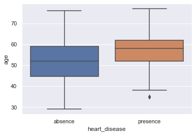

```python
# box plot of `age` based on heart disease
sns.boxplot(x=heartdf.heart_disease, y=heartdf.age)
plt.show();
```

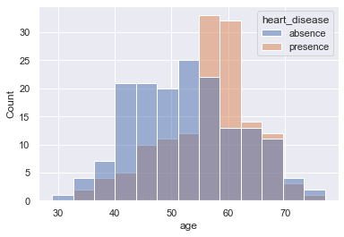

```python
# histogram of `age` based on heart disease
sns.histplot(data = heartdf , x='age' , hue = 'heart_disease')
plt.show();
```

```python
# create series for age hd and resting age no hd
age_hd = heartdf.age[heartdf.heart_disease == 'presence']
age_no_hd = heartdf.age[heartdf.heart_disease == 'absence']
```

```python
# run two-sample t-test
tstat, pval = ttest_ind(age_hd, age_no_hd)
print('p-value for `thalach` two-sample t-test: ', pval)
```

```
p-value for `thalach` two-sample t-test:  8.955636917529706e-05
```

**Cholestrol v/s Heart Disease**

```
Difference in mean Cholestrol :4.04
Difference in median Cholestrol :6
```

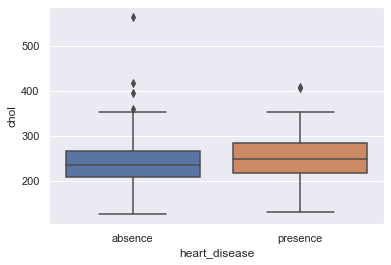

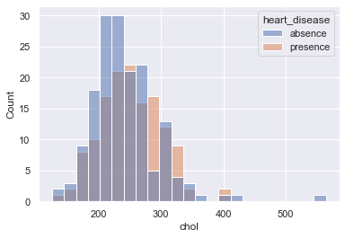

```python
# mean & median cholestrol by heart disease
chol_mean = heartdf.groupby("heart_disease")["chol"].mean()
chol_mean_diff = np.round((chol_mean[1]-chol_mean[0]),2)
print("Difference in mean Cholestrol :" + str(age_mean_diff))

chol_median = heartdf.groupby("heart_disease")["chol"].median()
chol_median_diff = np.round((chol_median[1]-chol_median[0]),2)
print("Difference in median Cholestrol :" + str(age_median_diff))

# box plot of `cholestrol` based on heart disease
sns.boxplot(x=heartdf.heart_disease, y=heartdf.chol)
plt.show();

# histogram of `cholestrol` based on heart disease
sns.histplot(data = heartdf , x='chol' , hue = 'heart_disease')
plt.show();
```

```python
# create series for cholestrol hd and resting age no hd
chol_hd = heartdf.chol[heartdf.heart_disease == 'presence']
chol_no_hd = heartdf.chol[heartdf.heart_disease == 'absence']

# run two-sample t-test
tstat, pval = ttest_ind(chol_hd, chol_no_hd)
print('p-value for `thalach` two-sample t-test: ', pval)
```

```
p-value for `thalach` two-sample t-test:  0.13914167020436527
```

*Inference : Median ages difer , p-value of 0.14 is > 0.05, so we “fail to reject the null hypothesis” and conclude that there is an in-significant difference in cholestrol for people with heart disease compared to people without heart disease*

## Chest Pain and Max Heart Rate

We will now investigate the relationship between thalach (maximum heart rate achieved during exercise) and the type of heart pain a person experiences

**Task 1 :**  
Create a set of side-by-side box plots of thalach for each chest pain type in the data

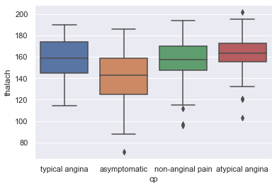

```python
# box plot of `thalach` based on `cp`
sns.boxplot(x=heartdf.cp, y=heartdf.thalach)
plt.show();
```

*Inference : Asymptomatic Chest Pain Patients have a "lower maximum heart rate" compated to others*

**We are investigating a relation between "Continuous Dependent Variable : Maximum Heart Rate" and Categorical Independent Varible : Chest Pain with various types". We will conduct a "One-Way-ANOVA Test"**

```python
# create series of `thalach` based on `cp` type
thalach_typical = heartdf.thalach[heartdf.cp == 'typical angina']
thalach_asymptom = heartdf.thalach[heartdf.cp == 'asymptomatic']
thalach_nonangin = heartdf.thalach[heartdf.cp == 'non-anginal pain']
thalach_atypical = heartdf.thalach[heartdf.cp == 'atypical angina']
```

```python
# run ANOVA test across groups (scipy.stats)
from scipy.stats import f_oneway
Fstat, pval = f_oneway(thalach_typical, thalach_asymptom, thalach_nonangin, thalach_atypical)
print('p-value for ANOVA: ', pval)
```

```
p-value for ANOVA:  1.9065505247705008e-10
```

```python
# run ANOVA test across groups (statsmodel)
# import the desired libraries
import statsmodels.api as sm
from statsmodels.formula.api import ols

# fit the model on data with "thalach" as DV and "chest pain" as IV
model = ols('thalach ~ cp', data=heartdf).fit()

# Produce the ANOVA Table
aov_table = sm.stats.anova_lm(model, typ=2)
aov_table
```

|  | sum_sq | df | F | PR(>F) |
| --- | --- | --- | --- | --- |
| cp | 23503.066135 | 3.0 | 17.413147 | 1.906551e-10 |
| Residual | 134523.197891 | 299.0 | NaN | NaN |

*Inference : At a significance level of 0.05 , we "Reject the Null Hypothesis" in favor of the Alternate Hypothesis and infer that at least one pair of Chest Pain Types have significantly different maximum heart rates during exercise*

```python
# run Tukey's range test
from statsmodels.stats.multicomp import pairwise_tukeyhsd
output = pairwise_tukeyhsd(heartdf.thalach, heartdf.cp)
print(output)
```

```
           Multiple Comparison of Means - Tukey HSD, FWER=0.05
=========================================================================
     group1           group2      meandiff p-adj   lower    upper  reject
-------------------------------------------------------------------------
    asymptomatic  atypical angina  21.7394  0.001  12.7439  30.735   True
    asymptomatic non-anginal pain  14.7264  0.001    7.258 22.1948   True
    asymptomatic   typical angina   15.276 0.0081   2.9702 27.5817   True
 atypical angina non-anginal pain   -7.013 0.2481 -16.7591   2.733  False
 atypical angina   typical angina  -6.4635 0.6069 -20.2707  7.3438  False
non-anginal pain   typical angina   0.5495    0.9  -12.315 13.4141  False
-------------------------------------------------------------------------
```

**For any pair where “Reject” is “True”, we conclude that people with those chest pain types have significantly different maximum heart rates during exercise**

*Inference : People who are "Asymptomatic" have a Lower Maximum heart rate (associated with heart disease) than people who have other kinds of chest pain.*

## Heart Disease and Chest Pain

We will now investigate the relationship between the kind of chest pain a person experiences and whether or not they have heart disease.  
Here we are investigating the association between two categorical variables that are independent i.e. patients are divided into two groups "having heart disease" and "not having heart disease".  
We will conduct Chi-Square Test to assess the significance of association between Heart Disease and Chest Pain

**Task 1 :**  
Create a contingency table of cp and heart_disease

```python
# contingency table of heart disease vs cp
Xtab = pd.crosstab(heartdf.cp, heartdf.heart_disease)
Xtab
```

| heart_disease cp | absence | presence |
| --- | --- | --- |
| asymptomatic | 39 | 105 |
| atypical angina | 41 | 9 |
| non-anginal pain | 68 | 18 |
| typical angina | 16 | 7 |

```python
# run chi-square test
from scipy.stats import chi2_contingency
chi2, pval, dof, exp = chi2_contingency(Xtab)
print('p-value for chi-square test: ', pval)
```

```
p-value for chi-square test:  1.2517106007837527e-17
```

*Inference : p-value of ~0, which is less than 0.05, so we can conclude that there is a significant association between these prevelence of heart disease and chest pain*

# Summary

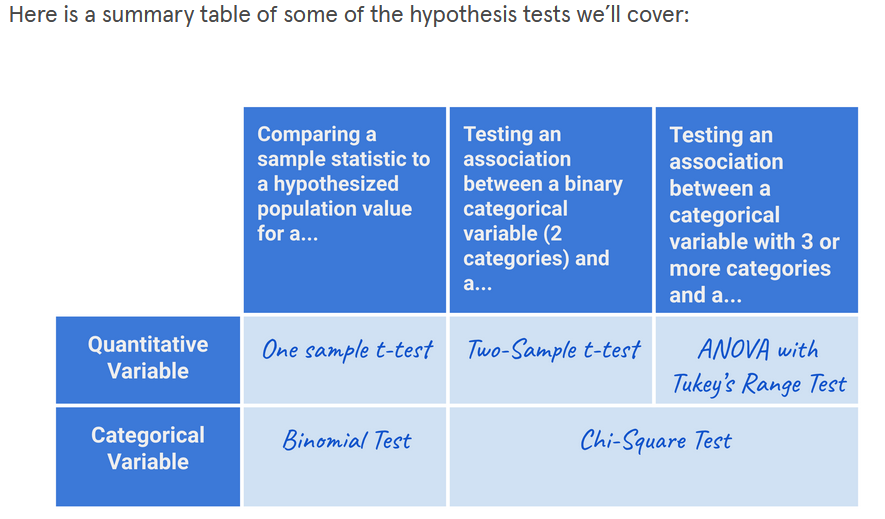

## Comparing a sample statistic to a hypothesized population value

In some situations, we may want to compare a sample statistic to a hypothesized population value. In this scenario, we have a sample of data from some population and have calculated a sample statistic (eg., a sample mean, frequency, or proportion). Based on this observed sample statistic, we then want to know whether the sample was likely to be drawn from a population with some hypothesized or target value of that same statistic. If we have a sample of quantitative data, such as height, weight, or amount spent, we should use a one-sample t-test. If we have a sample of binary data, such as whether or not someone made a purchase or clicked a link, we should use a binomial test.

**Example: one sample t-test**  
Suppose we want to compare exam scores for students who attended a test prep program to the global average score of 35 points. Do students who attend this program score higher than 35 points? The global average is the hypothesized population value and the average of the exam scores of students who attended the program is the sample statistic (in this case, sample mean).  
Below is the code to run a one-sample t-test to address the above question. In this example the alternative hypothesis is that the sample mean is significantly different than 35, and the null hypothesis is that the sample mean is 35.  
..............................................................  
from scipy.stats import ttest_1samp  
global_average_score = 35  
sample_scores = [12, 42, 37, 18, 23, 39, 45, … , 52]  
t_stat, p_value = ttest_1samp(sample_scores, global_average_score)  
...............................................................

**Example: binomial test**  
If we instead have a sample of binary data and want to compare a sample proportion/frequency to an underlying probability (population value), a binomial test is appropriate. The classic example of a binomial test is tossing a coin to determine if it’s fair (fair means that the probability of either heads or tails is exactly 50%).

For example, suppose that you collect sample data from a coin by tossing it 100 times, and find that 45 flips result in heads. Based on this sample, what is the probability that the coin is actually fair (if you flipped it infinitely many times, exactly half those flips would be heads)? The following code runs the binomial test to answer this question:  
.................................................................  
from scipy.stats import binom_test  
p_value = binom_test(45, 100, p = 0.50)  
The alternative hypothesis for this test is that the probability is different than p = 0.50, and the null is that it is equal to 0.50  
.................................................................  
Here are some other examples of situations where a binomial test would be useful

- Is the number of passengers who show up for a flight fewer than normal?
- Is the open rate on a marketing email different from the company target?